# Characteristics-driven returns in equilibrium

# 1 Introduction

This notebook presents the R code used for the paper [“*Characteristics-driven returns in equilibrium*”](https://papers.ssrn.com/sol3/papers.cfm?abstract_id=3941195).  
Only the strict minimum of material is provided.  
The **dataset** is available [here](https://drive.google.com/file/d/1_ZJj_y2qW8x1M_vTvZXrT3pcgvSrtdlK/view?usp=share_link).

# 2 Setup

First, we load packages & import the data.

```r
rstudioapi::writeRStudioPreference("data_viewer_max_columns", 200L)   # Allows to view up to 200 columns
```

```r
library(tidyverse)                                                    # Data wrangling package
library(readxl)                                                       # Read excel files
library(data.table)                                                   # Fast wrangling!
library(fst)                                                          # Fast reading & writing of dataframes
library(dtplyr)                                                       # Combining dplyr & data.table
library(lubridate)                                                    # Date management
library(ggallin)                                                      # Addin to ggplot for negative log scales
library(viridis)                                                      # Cool color palette
library(patchwork)                                                    # To layout graphs
library(latex2exp)                                                    # LaTeX in graphs
library(RcppEigen)                                                    # For fast linear models
library(reshape2)                                                     # List wrangling
library(Matrix)                                                       # High speed matrix manipulation
library(fastDummies)                                                  # For fixed effects

data_demand <- read_fst("data/data_demand.fst")                       # Loading main dataset
#data_demand <- read_fst("data/demand_macro.fst")                      # Loading main dataset

specs <- read_excel("data/ML_supp.xlsx")                              # Loading additional info
na_0 <- function(x){                                                  # Function that deals with missing points
    x[is.na(x)] <- 0                                                  # Values are in [-0.5,0.5], NAs => 0
    return(x)
}
data_demand <- data_demand %>%                                        # The above function is applied to the data
    mutate(across(3:ncol(data_demand), na_0))
```

```r
data_demand <- data_demand %>% filter(Date > "1984-06-01") # Stability filter
data_demand <- data_demand %>% arrange(Date, permno)       # Order
dates <- data_demand$Date %>% unique() %>% sort()          # Vector of dates
features <- specs %>%                                      # Predictors / firm characteristics
    #  filter(Frequency == "Monthly") %>%
    pull(Acronym)
#features <- c("mvel1", "bm", "mom12m")                    # Characteristics used in panel models
D_features <- paste0("D_", features)                       # Change in predictors
varz <- c(features, D_features)                            # List of all independent variables
#varz <- colnames(data_demand)[4:ncol(data_demand)]
```

# 3 Initialization of variables

Below, we create the objects in which we will store some results/outputs.  
Also, we fix the sample size used throughout the notebook!  
2 years means 24 monthly points. If there are roughly 5,000 firms in one sample, this makes 300k observations for one estimation.  
We recall that there are 93 characteristics + 93 changes thereof, which makes 186 predictors.

```r
sample <- 24                                                                  # Sample size (in months)
frequency <- 12                                                               # How often we estimate => every X months
dates_oos <- dates[sample:length(dates)]                                      # Out-of-sample dates
res_pool <- list()                                                            # Initialize results
res_fixed <- list()                                                           # Initialize results
R2_pool <- 0
R2_fixed <- 0
cor_series <- array(0, dim = c((length(dates_oos)-1),        # Initialize corr matrices, nb dates
                               length(varz) + 1,
                               length(varz) + 1))
cov_series <- array(0, dim = c((length(dates_oos)-1),        # Initialize cov matrices, nb dates
                               length(varz) + 1,
                               length(varz) + 1))
f_e <- c()                                                     # Initialize fixed effects
avg_ret_fac <- matrix(0, nrow = length(dates_oos)-1,           # Initialize average returns
                      ncol = 3)                                # We focus on 3 factors
avg_fe_fac <- matrix(0, nrow = length(dates_oos)-1,            # Initialize average fixed effects
                     ncol = 3 )
```

# 4 Useful functions

We rapidly source the custom functions we use below.

```r
source("func.R")
```

# 5 Pooled estimation

The loop below perform 4 tasks:  
1. perform the pooled estimations and store the corresponding estimates & metrics (e.g., $R^2$). *Pooled estimates are not reported in the latest version of the paper.*  
2. compute the correlations and covariances between the characteristics and their changes. (commented below) 3. estimate the model with fixed effects & store the values.  
4. compute the average return and average fixed effect of sorted portfolios on the rolling samples.

The loop is on the dates.  
We could make do without a loop via the **pmap**() function.  
But the complexity of the output is a bit deterring (this would generate a complex list).

```r
se_fe <- F
j <- 1
dates_used <- c()
avg_ret <- c()
features_sort <- c("mvel1", "bm", "mom12m")
tictoc::tic()
for(i in 1:(length(dates_oos)-2)){
    if(i %% 60 == 1){print(dates_oos[i])}                                      # Keeps track of progress
    data_train <- data_prep(data_demand, dates[i], dates_oos[i])               # Sample at time t
    data_test <- data_prep(data_demand, dates_oos[i+1], dates_oos[i+1])        # Test set: t+1
    data_test_0 <- data_train %>% filter(Date == dates_oos[i])                 # Test set: t
    avg_ret <- bind_rows(avg_ret,                                              # This stores the average returns in the sample
                         data_train |> group_by(permno) |>
                             summarise(avg_ret = mean(Return, na.rm = T)) |>
                             mutate(date = dates_oos[i]))
    y <- data_train$Return
    x <- data_train %>% select(all_of(varz)) %>% data.matrix()

    if(i %% frequency == 1){
        if(se_fe == T){
            d <- cbind(x, dummy_cols(data_train$permno)[,-1]) %>% data.matrix() %>% Matrix(sparse = T) # For fixed effects
            d <- t(d) %*% d
            nn <- ncol(x)
            NN <- ncol(d)
            d_inv <- solve(d)
            d_iag <- diag(d_inv)[(nn+1):NN]
        }
        if(se_fe == F){ d_iag <- NA}
        dates_used <- c(dates_used, as.character(dates_oos[i]))
        # The code below is for the pooled OLS estimations
        permnos <- data_train$permno %>% unique() %>% sort()                   # Keep model names
        pool_temp <- fit_lin(x = x, y = y, data_train$permno, permnos, as.character(dates_oos[i]), d_iag, "pooled")
        res_pool[[j]] <- pool_temp %>% mutate(sample = sample)                 # Storing estimation results
    }
    test_set <- intersect(data_test$permno, data_test_0$permno) %>%            # Common stocks for test
        intersect(permnos)
    pred_temp <- pred_lin(res = pool_temp,                                     # OOS prediction
                          x_new = data_test_0 %>%
                              filter(permno %in% test_set) %>%
                              select(all_of(varz)),
                          permno = test_set,
                          type = "pooled")
    target <- data_test %>% filter(permno %in% test_set) %>% pull(Return)      # OOS realization
    error <- pred_temp - target
    R2_pool[i] <- 1 - var(error) / var(target)

    ## Next we compute the correlations & covariances REMOVED TO SAVE TIME for baseline results
    ## cor_series[i,,] <- cor(data_train %>% select(-permno, -Date), use = "pairwise.complete.obs")   # Store the correlation matrix
    ## cov_series[i,,] <- cov(data_train %>% select(-permno, -Date), use = "pairwise.complete.obs")   # Store the covariance matrix

    if(i %% frequency == 1){
        # The code below pertains to the panel model
        fixed_temp <- fit_lin(x = x, y = y, data_train$permno, permnos, as.character(dates_oos[i]), d_iag, "fixed")   # Within estimation
        res_fixed[[j]] <- fixed_temp %>% mutate(sample = sample)
        # Finally, the average returns & average fixed-effects of the sorted portfolios
        for(k in 1:length(features_sort)){
            avg_ret_fac[i,k] <- sorted_metric(data_train, features_sort[k], "Return")           # Store the factor average return
            avg_fe_fac[i,k] <- sorted_metric(data = fixed_temp |> filter(field == "fe") |>      # Store the factor fixed effects
                                                 # bind_cols(f_e = fixef(fit_fe) %>% as.numeric(),
                                                 #              permno = unique(data_train$permno) %>% sort()) %>%
                                                 right_join(data_train |> select(permno, Date, mvel1, mom12m, bm),
                                                            by = "permno"),
                                             var = features_sort[k],
                                             metric = "value")
        }
        j <- j + 1
    }
    pred_temp <- pred_lin(res = fixed_temp,                       # OOS prediction
                          x_new = data_test_0 %>%
                              filter(permno %in% test_set) %>%
                              select(all_of(varz)),
                          permnos = test_set,
                          type = "fixed")
    error <- pred_temp - target                                                # OOS error
    R2_fixed[i] <- 1 - var(error) / var(target)                                # OOS R2
}
```

```
## [1] "1986-05-30"
## [1] "1991-05-31"
## [1] "1996-05-31"
## [1] "2001-05-31"
## [1] "2006-05-31"
## [1] "2011-05-31"
## [1] "2016-05-31"
## [1] "2021-05-28"
```

```r
tictoc::toc()
```

```
## 763.346 sec elapsed
```

```r
# save(avg_ret, file = paste0("avg_ret_", sample, ".RData"))
# save(avg_ret_fac, file = paste0("avg_ret_fac_", sample, ".RData"))
# save(avg_fe_fac, file = paste0("avg_fe_fac_", sample, ".RData"))
```

Below, we wrangle the output, for estimation outputs (estimates, t-stats, p-values) and $R^2$ separately.

```r
res_pool <- bind_rows(res_pool)
res_fixed <- bind_rows(res_fixed)
```

Saving important results below for future use.

```r
model <- "linear"
spec <- "simple"

res_full <-
    bind_rows(
        res_pool %>% mutate(type = "pooled",
                            model = model,
                            spec = spec,
                            date = as.Date(date)),
        res_fixed %>% mutate(type = "fixed",
                             model = model,
                             spec = spec,
                             date = as.Date(date)),
        data.frame(value = R2_pool,
                   factor = NA,
                   field = "R2_oos",
                   date = dates_oos[1:(length(dates_oos)-2)],
                   permno = NA,
                   sample = sample,
                   type = "pooled",
                   model = model,
                   spec = spec),
        data.frame(value = R2_fixed,
                   factor = NA,
                   field = "R2_oos",
                   date = dates_oos[1:(length(dates_oos)-2)],
                   permno = NA,
                   sample = sample,
                   type = "fixed",
                   model = model,
                   spec = spec)
    )
save(res_full, file = paste0("res_full_linear_",sample,".RData"))
```

# 6 Time-series plots of t-stats

**NOTE**: we recall that pooled estimates are not reported in the latest version of the paper.

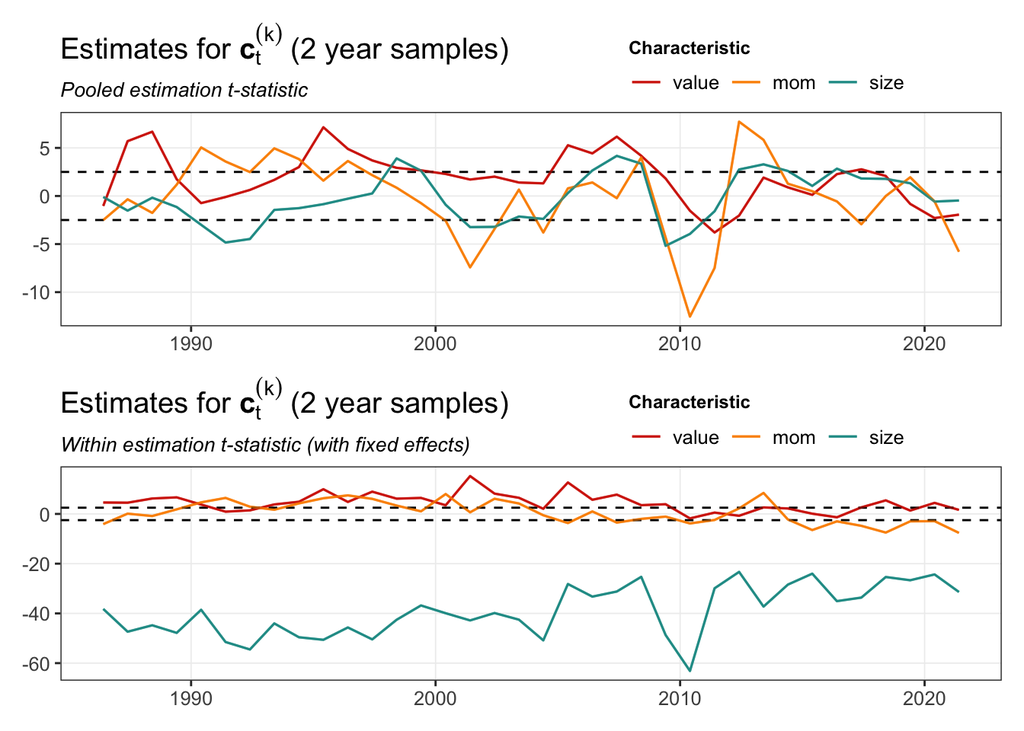

```r
g1 <- res_full %>%
    filter(field == "t_stat",
           factor %in% c("mom12m", "mvel1", "bm"),
           type == "pooled") %>%
    ggplot(aes(x = date, y = value, color = factor)) + geom_line() + theme_bw() +
    geom_hline(yintercept = 2.5, linetype = 2) +                                                 # Upper 1% threshold
    geom_hline(yintercept = -2.5, linetype = 2) +                                                # Lower 1% threshold
    theme(legend.position = c(0.75, 1.2),                                                        # Legend position
          text = element_text(size = 12),                                                        # Overall text size
          plot.title = element_text(face = "bold"),                                              # Bold title
          legend.title = element_text(face = "bold", size = 9),                                  # Title font size for the legend
          plot.subtitle = element_text(size = 10, face = "italic"),                              # Italic subtitle
          axis.title.x = element_blank(),                                                        # No x-axis title (obvious)
          axis.title.y = element_blank(),                                                        # No y-axis title (=title)
          panel.grid.major = element_line(size = 0.3, linetype = 'solid', colour = "#EEEEEE"),   # Grid adjustment
          panel.grid.minor = element_line(size = 0.1, linetype = 'solid', colour = "#FFFFFF")) + # Grid adjustment
    geom_line(alpha = 0.6, size = 0.6) + labs(subtitle = "Pooled estimation t-statistic") +      # Lines + subtitle
    scale_color_manual(values = c("#D5280C", "#FC9203", "#219B96"),
                       labels = c("value", "mom", "size"),
                       name = "Characteristic") +
    ggtitle(TeX("Estimates for $\\textbf{c}_t^{(k)}$ (2 year samples)")) +
    guides(colour = guide_legend(nrow = 1))

g2 <- res_full %>%
    filter(field == "t_stat",
           factor %in% c("mom12m", "mvel1", "bm"),
           type == "fixed") %>%
    ggplot(aes(x = date, y = value, color = factor)) + geom_line() + theme_bw() +
    geom_hline(yintercept = 2.5, linetype = 2) +                                                 # Upper 1% threshold
    geom_hline(yintercept = -2.5, linetype = 2) +                                                # Lower 1% threshold
    theme(legend.position =  c(0.75, 1.2),                                                       # Legend position
          text = element_text(size = 12),                                                        # Overall text size
          plot.title = element_text(face = "bold"),                                              # Bold title
          legend.title = element_text(face = "bold", size = 9),                                  # Title font size for the legend
          plot.subtitle = element_text(size = 10, face = "italic"),                              # Italic subtitle
          axis.title.x = element_blank(),                                                        # No x-axis title (obvious)
          axis.title.y = element_blank(),                                                        # No y-axis title (=title)
          panel.grid.major = element_line(size = 0.3, linetype = 'solid', colour = "#EEEEEE"),   # Grid adjustment
          panel.grid.minor = element_line(size = 0.1, linetype = 'solid', colour = "#FFFFFF")) + # Grid adjustment
    geom_line(alpha = 0.6, size = 0.6) +
    labs(subtitle = "Within estimation t-statistic (with fixed effects)") +                      # Lines + subtitle
    scale_color_manual(values = c("#D5280C", "#FC9203", "#219B96"),
                       labels = c("value", "mom", "size"),
                       name = "Characteristic") +
    ggtitle(TeX("Estimates for $\\textbf{c}_t^{(k)}$ (2 year samples)")) +
    guides(colour = guide_legend(nrow = 1))
g1/g2
```

```r
#ggsave("t_stats_1y.pdf")
```

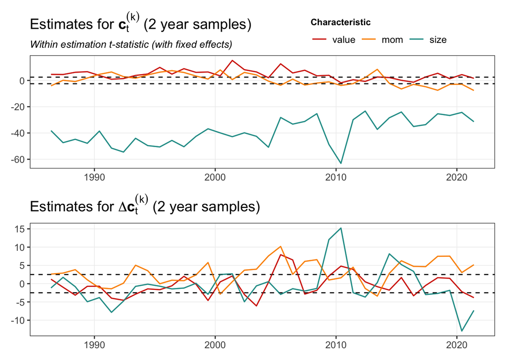

```r
g3 <- res_full %>%
    filter(field == "t_stat",
           factor %in% c("D_mom12m", "D_mvel1", "D_bm"),
           type == "pooled") %>%
    ggplot(aes(x = date, y = value, color = factor)) + geom_line() + theme_bw() +
    geom_hline(yintercept = 2.5, linetype = 2) +                                                 # Upper 1% threshold
    geom_hline(yintercept = -2.5, linetype = 2) +                                                # Lower 1% threshold
    theme(legend.position = c(0.75, 1.2),                                                        # Legend position
          text = element_text(size = 12),                                                        # Overall text size
          plot.title = element_text(face = "bold"),                                              # Bold title
          legend.title = element_text(face = "bold", size = 9),                                  # Title font size for the legend
          plot.subtitle = element_text(size = 10, face = "italic"),                              # Italic subtitle
          axis.title.x = element_blank(),                                                        # No x-axis title (obvious)
          axis.title.y = element_blank(),                                                        # No y-axis title (=title)
          panel.grid.major = element_line(size = 0.3, linetype = 'solid', colour = "#EEEEEE"),   # Grid adjustment
          panel.grid.minor = element_line(size = 0.1, linetype = 'solid', colour = "#FFFFFF")) + # Grid adjustment
    geom_line(alpha = 0.6, size = 0.6) + labs(subtitle = "Pooled estimation t-statistic") +      # Lines + subtitle
    scale_color_manual(values = c("#D5280C", "#FC9203", "#219B96"),
                       labels = c("value", "mom", "size"),
                       name = "Characteristic") +
    ggtitle(TeX("Estimates for $\\Delta \\textbf{c}_t^{(k)}$ (2 year samples)")) +
    guides(colour = guide_legend(nrow = 1))

g4 <- res_full %>%
    filter(field == "t_stat",
           factor %in% c("D_mom12m", "D_mvel1", "D_bm"),
           type == "fixed") %>%
    ggplot(aes(x = date, y = value, color = factor)) + geom_line() + theme_bw() +
    geom_hline(yintercept = 2.5, linetype = 2) +                                                 # Upper 1% threshold
    geom_hline(yintercept = -2.5, linetype = 2) +                                                # Lower 1% threshold
    theme(legend.position = "none",                                                              # Legend position
          text = element_text(size = 12),                                                        # Overall text size
          plot.title = element_text(face = "bold"),                                              # Bold title
          legend.title = element_text(face = "bold", size = 9),                                  # Title font size for the legend
          plot.subtitle = element_text(size = 10, face = "italic"),                              # Italic subtitle
          axis.title.x = element_blank(),                                                        # No x-axis title (obvious)
          axis.title.y = element_blank(),                                                        # No y-axis title (=title)
          panel.grid.major = element_line(size = 0.3, linetype = 'solid', colour = "#EEEEEE"),   # Grid adjustment
          panel.grid.minor = element_line(size = 0.1, linetype = 'solid', colour = "#FFFFFF")) + # Grid adjustment
    geom_line(alpha = 0.6, size = 0.6) +
    #labs(subtitle = "Within estimation t-statistic (with fixed effects)") +                      # Lines + subtitle
    scale_color_manual(values = c("#D5280C", "#FC9203", "#219B96"),
                       labels = c("value", "mom", "size"),
                       name = "Characteristic") +
    ggtitle(TeX("Estimates for $\\Delta \\textbf{c}_t^{(k)}$ (2 year samples)")) +
    guides(colour = guide_legend(nrow = 1))
g2/g4
```

```r
#ggsave("t_stats_2y.pdf", width = 8, height = 5)
```